# CS 422 HW4

Sesha Shai Datta Kolli, Illinois Institute of Technology

```r
library ('plyr')
library('dplyr')
library(caret)
library(rpart)
library(rpart.plot)
library(pROC)
library(ROCR)
options(digits = 3)
set.seed(1122)
setwd("D:/Masters/DM/HW4")
train <- read.csv(file="adult-train.csv")
test <- read.csv(file="adult-test.csv")
data.frame(train)
```

| age | workclass | fnlwgt | education | education_num | marital_status | occupation | relationship | race | sex | capital_gain | capital_loss | hours_per_week | native_country | income |
| --- | --- | --- | --- | --- | --- | --- | --- | --- | --- | --- | --- | --- | --- | --- |
| 39 | State-gov | 77516 | Bachelors | 13 | Never-married | Adm-clerical | Not-in-family | White | Male | 2174 | 0 | 40 | United-States | <=50K |
| 50 | Self-emp-not-inc | 83311 | Bachelors | 13 | Married-civ-spouse | Exec-managerial | Husband | White | Male | 0 | 0 | 13 | United-States | <=50K |
| 38 | Private | 215646 | HS-grad | 9 | Divorced | Handlers-cleaners | Not-in-family | White | Male | 0 | 0 | 40 | United-States | <=50K |
| 53 | Private | 234721 | 11th | 7 | Married-civ-spouse | Handlers-cleaners | Husband | Black | Male | 0 | 0 | 40 | United-States | <=50K |
| 28 | Private | 338409 | Bachelors | 13 | Married-civ-spouse | Prof-specialty | Wife | Black | Female | 0 | 0 | 40 | Cuba | <=50K |
| 37 | Private | 284582 | Masters | 14 | Married-civ-spouse | Exec-managerial | Wife | White | Female | 0 | 0 | 40 | United-States | <=50K |
| 49 | Private | 160187 | 9th | 5 | Married-spouse-absent | Other-service | Not-in-family | Black | Female | 0 | 0 | 16 | Jamaica | <=50K |
| 52 | Self-emp-not-inc | 209642 | HS-grad | 9 | Married-civ-spouse | Exec-managerial | Husband | White | Male | 0 | 0 | 45 | United-States | >50K |
| 31 | Private | 45781 | Masters | 14 | Never-married | Prof-specialty | Not-in-family | White | Female | 14084 | 0 | 50 | United-States | >50K |
| 42 | Private | 159449 | Bachelors | 13 | Married-civ-spouse | Exec-managerial | Husband | White | Male | 5178 | 0 | 40 | United-States | >50K |

[output cut: 990 more lines]

### Part 2.1-A

```r
rdata<-function(data){
  cn=ldply(data, function(c) sum(c =="?"))
  cn=cn$.id[cn$V1>0]
  indices<-list()
  for(c in cn){
    cat('Total Number of "?" in',c,': ',sum(data[c]=='?'),'\n')
    indices <- c(indices, which(data[c]=='?'))
  }
  indices<-unique(indices)
  data<-data %>% slice(-c(unlist(indices)))
  cat('No of rows after cleaning',nrow(data),'\n\n')
  return(data)
}

train<-rdata(train)
```

```
Total Number of "?" in workclass :  1836
Total Number of "?" in occupation :  1843
Total Number of "?" in native_country :  583
No of rows after cleaning 30161
```

```r
test<-rdata(test)
```

```
Total Number of "?" in workclass :  963
Total Number of "?" in occupation :  966
Total Number of "?" in native_country :  274
No of rows after cleaning 15060
```

### Part 2.1-B

```r
set.seed(1122)
```

### Part 2.1-B-i

```r
model<-rpart(income ~ ., data = train)
print(model$variable.importance[1:3])
```

```
  relationship marital_status   capital_gain
          2277           2242            973
```

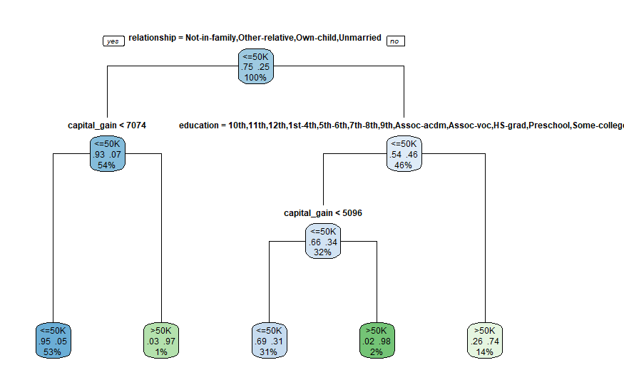

```r
rpart.plot(model,type = 1,extra=104)
```

### Part 2.1-B-ii

#### The first split is done on the ‘relationship’ predictor and it is the root node of the decision tree. The ‘<=50k’ is the predicted class of the root node. The distribution of observation of the root node for class ‘<=50k’ is 75% and for the ‘>50k’ is 25%.

### Part 2.1-C

```r
ypred<- predict(model,newdata=test,type='class')
confusion_matrix <- confusionMatrix(ypred, as.factor(test$income))
confusion_matrix
```

```
Confusion Matrix and Statistics

          Reference
Prediction <=50K  >50K
     <=50K 10772  1837
     >50K    588  1863

               Accuracy : 0.839
                 95% CI : (0.833, 0.845)
    No Information Rate : 0.754
    P-Value [Acc > NIR] : <2e-16

                  Kappa : 0.51

 Mcnemar's Test P-Value : <2e-16

            Sensitivity : 0.948
            Specificity : 0.504
         Pos Pred Value : 0.854
         Neg Pred Value : 0.760
             Prevalence : 0.754
         Detection Rate : 0.715
   Detection Prevalence : 0.837
      Balanced Accuracy : 0.726

       'Positive' Class : <=50K
```

### Part 2.1-C-i

#### Balanced accuracy

```r
balanced_accuracy<- (confusion_matrix$byClass['Sensitivity']+ confusion_matrix$byClass['Specificity'])/2
cat("The Balanced accuracy is",as.numeric(balanced_accuracy))
```

```
The Balanced accuracy is 0.726
```

### Part 2.1-C-ii

```r
balanced_error=as.numeric(1- balanced_accuracy)
cat("The Balanced error rate is:",balanced_error)
```

```
The Balanced error rate is: 0.274
```

### Part 2.1-C-iii

```r
cat("Sensitivity",confusion_matrix$byClass['Sensitivity'])
```

```
Sensitivity 0.948
```

```r
cat("\nSpecificity",confusion_matrix$byClass['Specificity'])
```

```
Specificity 0.504
```

### Part 2.1-C-iv

#### The ROC curve is an graphical representation of trade-off between TPR and FPR of a classifier. In the curve the TPR is on y-axis and FPR is on x-axis.

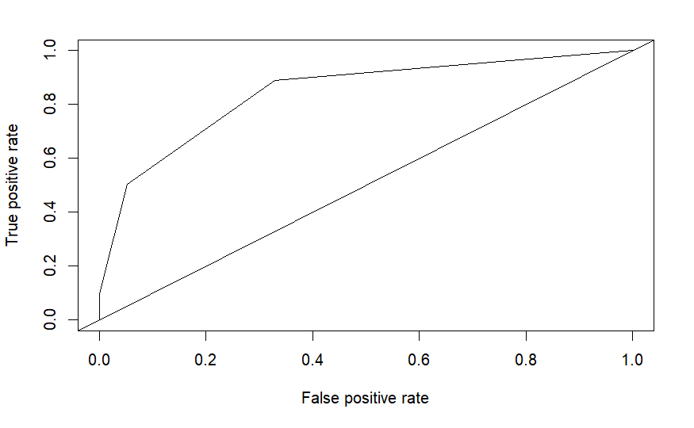

```r
library(pROC)
library(ROCR)
ypred<-predict(model,newdata = test,type="prob")

s<-test$income
s[s=="<=50K"]<-0
s[s==">50K"]<-1
s<-as.numeric(s)
pred = prediction(ypred[,2], s)
perf <- performance(pred,"tpr","fpr")

roc = performance(pred,"tpr","fpr")
plot(roc)
abline(a = 0, b = 1)
```

```r
auc = performance(pred, measure = "auc")
print(auc@y.values)
```

```
[[1]]
[1] 0.843
```

### Part 2.1-D

```r
library(rpart)
printcp(model)
```

```
Classification tree:
rpart(formula = income ~ ., data = train)

Variables actually used in tree construction:
[1] capital_gain education    relationship

Root node error: 7508/30161 = 0.2

n= 30161

    CP nsplit rel error xerror  xstd
1 0.13      0       1.0    1.0 0.010
2 0.06      2       0.7    0.7 0.009
3 0.04      3       0.7    0.7 0.009
4 0.01      4       0.6    0.6 0.008
```

```r
cat('Optimal CP value:', model$cptable[which.min(model$cptable[,'xerror']),'CP'])
```

```
Optimal CP value: 0.01
```

The pruning is a technique which is used to reduce the size of the decision tree, this can be done by eleminating weight connections in network to speed up and reduce model storage size. This can be used reduce the model complexity and also reduces the overfitting. The pruning is done with the help of the complexity parameter(cp).The cp is used to choose the optimal tree size and can control the size of the decision tree. The cost of adding new node to a decision tree from current nodeis the value of cp then the tree building does not continue.

The further pruning does not benifit because the default cp value is 0.01, the relative error is 0.63852, with reduce in cp value the relative error may decrese with the increse in complexity of the decision tree, in here the chance of overfitting is more. By seeing the cp table the increase in the cp value has the increase in the relative error, pruning is not possible with higher cp values.

### Part 2.1-E

```r
set.seed(1122)
```

### Part 2.1-E-i

```r
cat("In training dataset,The no of observations of class '<=50K' is:",sum(train$income =="<=50K"))
```

```
In training dataset,The no of observations of class '<=50K' is: 22653
```

```r
cat("\nIn training dataset, The no of observations  class '>50K' is:",sum(train$income ==">50K"))
```

```
In training dataset, The no of observations  class '>50K' is: 7508
```

### Part 2.1-E-ii

```r
t_subset<- train[sample(which(train$income=="<=50K"),sum(train$income==">50K")),]
new_train_dataset<-rbind(t_subset,train[train$income==">50K",])
new_train_dataset
```

|  | age | workclass | fnlwgt | education | education_num | marital_status | occupation | relationship | race | sex | capital_gain | capital_loss | hours_per_week | native_country | income |
| --- | --- | --- | --- | --- | --- | --- | --- | --- | --- | --- | --- | --- | --- | --- | --- |
| 6742 | 60 | Local-gov | 232769 | 11th | 7 | Married-civ-spouse | Transport-moving | Husband | White | Male | 0 | 0 | 20 | United-States | <=50K |
| 1221 | 29 | Private | 285290 | 11th | 7 | Never-married | Other-service | Unmarried | Black | Female | 0 | 0 | 40 | United-States | <=50K |
| 15115 | 58 | Private | 317479 | HS-grad | 9 | Divorced | Machine-op-inspct | Not-in-family | Black | Female | 0 | 0 | 40 | United-States | <=50K |
| 12467 | 65 | Private | 225580 | HS-grad | 9 | Divorced | Sales | Not-in-family | White | Female | 0 | 0 | 20 | United-States | <=50K |
| 15143 | 29 | Private | 131310 | Assoc-acdm | 12 | Never-married | Sales | Own-child | White | Female | 0 | 0 | 40 | United-States | <=50K |
| 25350 | 30 | Private | 194827 | Some-college | 10 | Married-civ-spouse | Craft-repair | Husband | White | Male | 0 | 1740 | 40 | United-States | <=50K |
| 163 | 27 | Private | 253814 | HS-grad | 9 | Married-spouse-absent | Sales | Unmarried | White | Female | 0 | 0 | 25 | United-States | <=50K |
| 29049 | 60 | Private | 232242 | HS-grad | 9 | Married-civ-spouse | Sales | Husband | White | Male | 0 | 0 | 40 | United-States | <=50K |
| 8306 | 39 | Private | 67136 | Assoc-voc | 11 | Separated | Adm-clerical | Not-in-family | Asian-Pac-Islander | Male | 0 | 0 | 40 | United-States | <=50K |
| 26125 | 35 | Self-emp-not-inc | 238802 | HS-grad | 9 | Married-civ-spouse | Farming-fishing | Husband | White | Male | 0 | 0 | 50 | United-States | <=50K |

[output cut: 990 more lines]

```r
sum(new_train_dataset$income =="<=50K")
```

```
[1] 7508
```

```r
sum(new_train_dataset$income ==">50K")
```

```
[1] 7508
```

### Part 2.1-E-iii

```r
new_model<-rpart(income ~ ., data = new_train_dataset)
n_pred=predict(new_model,test,type = "class")
confusion_matrix <- confusionMatrix(n_pred, as.factor(test$income))
confusion_matrix
```

```
Confusion Matrix and Statistics

          Reference
Prediction <=50K >50K
     <=50K  8433  491
     >50K   2927 3209

               Accuracy : 0.773
                 95% CI : (0.766, 0.78)
    No Information Rate : 0.754
    P-Value [Acc > NIR] : 3.85e-08

                  Kappa : 0.499

 Mcnemar's Test P-Value : < 2e-16

            Sensitivity : 0.742
            Specificity : 0.867
         Pos Pred Value : 0.945
         Neg Pred Value : 0.523
             Prevalence : 0.754
         Detection Rate : 0.560
   Detection Prevalence : 0.593
      Balanced Accuracy : 0.805

       'Positive' Class : <=50K
```

### Part 2.1-E-iii-i

```r
balanced_accuracy<- (confusion_matrix$byClass['Sensitivity']+ confusion_matrix$byClass['Specificity'])/2
cat("The Balanced accuracy is",as.numeric(balanced_accuracy))
```

```
The Balanced accuracy is 0.805
```

### Part 2.1-E-iii-ii

```r
balanced_error=as.numeric(1- balanced_accuracy)
cat("The Balanced error rate is:",balanced_error)
```

```
The Balanced error rate is: 0.195
```

### Part 2.1-E-iii-iii

```r
cat("Sensitivity",confusion_matrix$byClass['Sensitivity'])
```

```
Sensitivity 0.742
```

```r
cat("\nSpecificity",confusion_matrix$byClass['Specificity'])
```

```
Specificity 0.867
```

### Part 2.1-E-iii-iv

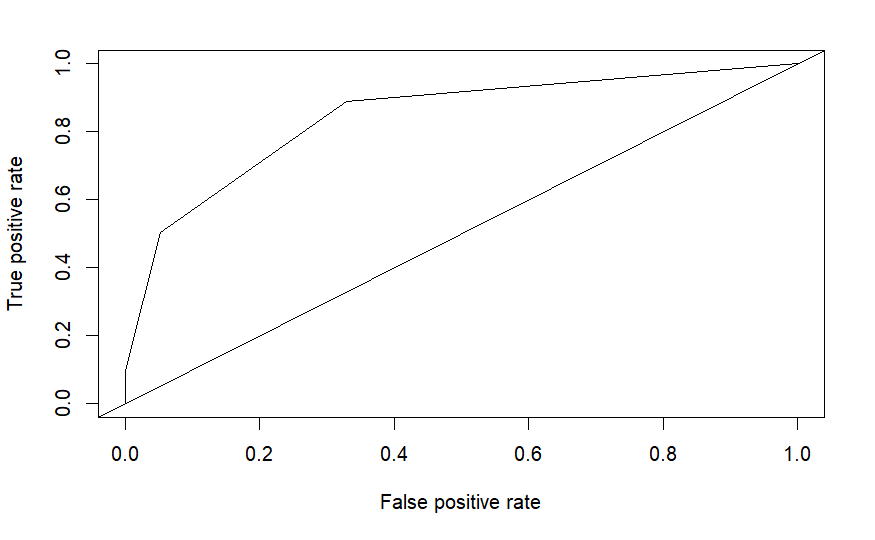

```r
ypred<-predict(model,newdata = test,type="prob")

s<-test$income
s[s=="<=50K"]<-0
s[s==">50K"]<-1
s<-as.numeric(s)
pred = prediction(ypred[,2], s)
perf <- performance(pred,"tpr","fpr")

roc = performance(pred,"tpr","fpr")
plot(roc)
abline(a = 0, b = 1)
```

```r
auc = performance(pred, measure = "auc")
cat("The AUC is",auc@y.values[[1]])
```

```
The AUC is 0.843
```

### Part 2.1-F

positive predictors value of (c) is 0.854 is small than the positive predictor value of the (e) 0.945.